# In-Class Session 8: Panel Data, Fixed Effects, and Event Studies

Econometrics I

This notebook reproduces the simulations behind Lectures 8a and 8b (the slides use `panel_sims.R`, which runs essentially the same simulations with more plotting) and leaves you four short problems. Everything is simulated, so you always know the right answer.

# Part 1: Panel data and fixed effects

## Reproduce: the management-practices panel

Firm quality $\alpha_i$ raises productivity *and* makes firms adopt better practices. The true effect of practices on log productivity is $\beta = 0.10$.

```r
beta_true <- 0.10
sim_panel <- function(N = 200, T = 8, rho = 0.7, sd_alpha = 0.5, sd_eps = 0.3, me_sd = 0) {
  alpha <- rnorm(N, 0, sd_alpha)
  gamma <- rnorm(T, 0, 0.1)
  d <- CJ(firm = 1:N, year = 1:T)
  d[, alpha := alpha[firm]]
  d[, x := rho * alpha + sqrt(1 - rho^2) * (rnorm(N)[firm] * 0.6) + rnorm(.N, 0, 0.8)]
  d[, y := 1 + beta_true * x + alpha + gamma[year] + rnorm(.N, 0, sd_eps)]
  if (me_sd > 0) d[, x := x + rnorm(.N, 0, me_sd)]
  d[]
}
d <- sim_panel()
```

Pooled OLS, the within (FE) estimator, and first differences:

```r
fit_pooled <- feols(y ~ x, d, cluster = ~firm)
fit_fe     <- feols(y ~ x | firm + year, d, cluster = ~firm)
fit_fd     <- feols(d(y) ~ d(x), d, panel.id = ~firm + year, cluster = ~firm)
etable(fit_pooled, fit_fe, fit_fd, headers = c("pooled", "within", "first diff"))
```

```
##                         fit_pooled             fit_fe             fit_fd
##                             pooled             within         first diff
## Dependent Var.:                  y                  y               d(y)
##
## Constant        0.9754*** (0.0351)                     -0.0074. (0.0044)
## x               0.2851*** (0.0263) 0.0933*** (0.0103)
## d(x)                                                  0.0791*** (0.0117)
## Fixed-Effects:  ------------------ ------------------ ------------------
## firm                            No                Yes                 No
## year                            No                Yes                 No
## _______________ __________________ __________________ __________________
## S.E.: Clustered           by: firm           by: firm           by: firm
## Observations                 1,600              1,600              1,400
## R2                         0.17437            0.81198            0.04051
## Within R2                       --            0.05957                 --
## ---
## Signif. codes: 0 '***' 0.001 '**' 0.01 '*' 0.05 '.' 0.1 ' ' 1
```

## Reproduce: random effects by hand

Random effects is GLS with equicorrelated errors, which is OLS after *quasi*-demeaning with weight $\theta = 1 - \sqrt{\sigma^2_\varepsilon / (\sigma^2_\varepsilon + T\sigma^2_\alpha)}$. Estimate the two variances from the within and between regressions (Swamy–Arora), then transform. Year effects stay in, as in `fit_fe`, so the comparison with FE is like-for-like.

```r
re_fit <- function(d) {
  within <- feols(y ~ x | firm + year, d)       # two-way, like fit_fe
  s2_eps <- sum(resid(within)^2) / (nrow(d) - uniqueN(d$firm) - uniqueN(d$year))
  b <- d[, .(ybar = mean(y), xbar = mean(x), T_i = .N), by = firm]
  between <- lm(ybar ~ xbar, b)
  s2_alpha <- max(0, sum(resid(between)^2) / between$df.residual - s2_eps / mean(b$T_i))
  d <- merge(d, b, by = "firm")
  d[, theta := 1 - sqrt(s2_eps / (s2_eps + T_i * s2_alpha))]
  fit <- lm(I(y - theta * ybar) ~ I(x - theta * xbar) + factor(year), d)
  list(beta = unname(coef(fit)[2]), se = unname(sqrt(diag(vcov(fit)))[2]),
       theta = mean(d$theta), s2_eps = s2_eps, s2_alpha = s2_alpha)
}
re <- re_fit(d)
str(re)
```

```
## List of 5
##  $ beta    : num 0.11
##  $ se      : num 0.0101
##  $ theta   : num 0.762
##  $ s2_eps  : num 0.0946
##  $ s2_alpha: num 0.196
```

Compare $\hat\theta$ to the true $\theta = 1 - \sqrt{0.09/(0.09 + 8 \cdot 0.25)} = 0.79$: with $T = 8$ and $\sigma^2_\alpha / \sigma^2_\varepsilon \approx$ 2.08, RE is already most of the way to FE. Yet it is biased, because $\alpha_i$ is correlated with $x$.

## Reproduce: Mundlak (correlated random effects)

Add the firm mean of $x$ as a regressor. The coefficient on $x_{it}$ is the FE estimate; the coefficient on $\bar x_i$ is a cluster-robust Hausman test.

```r
d[, xbar := mean(x), by = firm]
fit_mund <- feols(y ~ x + xbar | year, d, cluster = ~firm)
etable(fit_fe, fit_mund, headers = c("within", "Mundlak"))
```

```
##                             fit_fe           fit_mund
##                             within            Mundlak
## Dependent Var.:                  y                  y
##
## x               0.0933*** (0.0103) 0.0933*** (0.0103)
## xbar                               0.5420*** (0.0578)
## Fixed-Effects:  ------------------ ------------------
## firm                           Yes                 No
## year                           Yes                Yes
## _______________ __________________ __________________
## S.E.: Clustered           by: firm           by: firm
## Observations                 1,600              1,600
## R2                         0.81198            0.34111
## Within R2                  0.05957            0.32940
## ---
## Signif. codes: 0 '***' 0.001 '**' 0.01 '*' 0.05 '.' 0.1 ' ' 1
```

## Reproduce: partial pooling of store effects

Sixty stores with very different amounts of data. The partial-pooling estimate shrinks each store’s mean toward the grand mean; the weight on its own mean is its reliability (the signal share of the variance of its mean).

```r
S <- 60; alpha <- rnorm(S, 0, 0.4); n_s <- sample(c(4, 8, 16, 32, 64), S, replace = TRUE)
ybar <- alpha + rnorm(S, 0, 1 / sqrt(n_s)); grand <- mean(ybar)
s2_alpha <- max(0, var(ybar) - mean(1 / n_s))                     # method of moments, sigma_eps^2 = 1 known
w <- s2_alpha / (s2_alpha + 1 / n_s); eb <- grand + w * (ybar - grand)
c(no_pooling = mean((ybar - alpha)^2), complete = mean((grand - alpha)^2), partial = mean((eb - alpha)^2))
```

```
## no_pooling   complete    partial
## 0.10403585 0.15647279 0.05656689
```

```r
rbind(top5_by_mean_n = n_s[order(-ybar)][1:5], top5_by_partial_n = n_s[order(-eb)][1:5])
```

```
##                   [,1] [,2] [,3] [,4] [,5]
## top5_by_mean_n      16    4    4    8    8
## top5_by_partial_n   16   64   16   32   64
```

# In-class problem 1: turn the correlation off and on

Re-simulate with `rho = 0` (no correlation between quality and practices) and with `rho = 0.9`. For each, report pooled, within, and RE estimates. Which estimator moves, and which stays put? Then explain in one sentence what the RE assumption is buying you when `rho = 0`.

```r
# your code here
```

# In-class problem 2: measurement error

Re-simulate with `rho = 0` and `me_sd = 1` (noise added to the observed practices score). Now pooled OLS has no omitted-variable problem. Compare pooled and within estimates to $0.10$. Which is more attenuated, and why does demeaning make measurement error worse? (Hint: what does demeaning do to the *signal* variance of $x$ versus the *noise* variance?)

```r
# your code here
```

# Part 2: Event studies

## Reproduce: the single-timing event study

400 firms, 24 quarters. Half adopt a pricing tool in quarter 13; the effect ramps from 0.0125 to 0.05 over four quarters. Never-treated firms get the reference value of event time so they stay in the regression and identify the period effects.

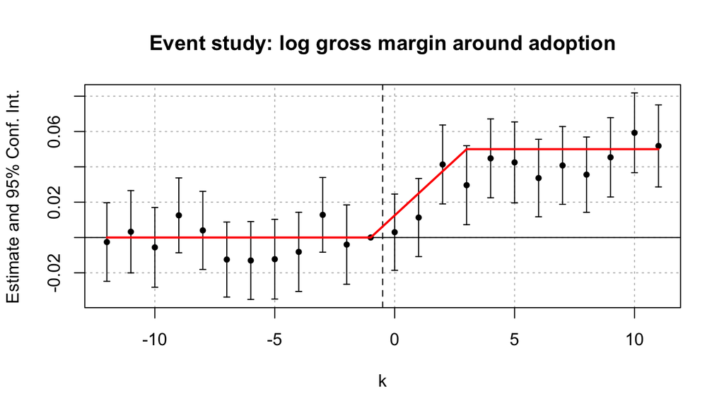

```r
tau_true <- function(k) ifelse(k >= 0, 0.05 * pmin(1, (k + 1) / 4), 0)
sim_es <- function(N = 400, T = 24, E0 = 13, trend = 0, anticipate = 0, sd_eps = 0.08) {
  d <- CJ(firm = 1:N, t = 1:T)
  d[, treated := as.integer(firm <= N / 2)]
  d[, alpha := rnorm(N, 0, 0.3)[firm]]
  gam <- cumsum(rnorm(T, 0.005, 0.02))
  d[, k := ifelse(treated == 1, t - E0, -1L)]          # controls carry the reference value
  d[, tau := ifelse(treated == 1, tau_true(t - E0), 0)]
  if (anticipate > 0) d[treated == 1 & (t - E0) < 0 & (t - E0) >= -anticipate, tau := 0.0125]
  d[, y := alpha + gam[t] + tau + trend * treated * (t - E0) + rnorm(.N, 0, sd_eps)]
  d[]
}
es <- sim_es()
fit_es <- feols(y ~ i(k, ref = -1) | firm + t, es, cluster = ~firm)
iplot(fit_es, ref.line = -0.5, main = "Event study: log gross margin around adoption")
lines(-12:11, tau_true(-12:11), col = "red", lwd = 2)
```

The joint test on the pre-period coefficients, and the static two-way FE coefficient for comparison:

```r
wald(fit_es, keep = "k::-")
```

```
## Wald test, H0: joint nullity of k::-12, k::-11, k::-10, k::-9, k::-8, k::-7 and 5 others
##  stat = 1.23466, p-value = 0.257236, on 11 and 9,154 DoF, VCOV: Clustered (firm).
```

```r
es[, post := treated * (t >= 13)]
coef(feols(y ~ post | firm + t, es, cluster = ~firm))
```

```
##       post
## 0.03871171
```

```r
mean(tau_true(0:11))    # what the static coefficient is averaging
```

```
## [1] 0.04375
```

# In-class problem 3: anticipation

Re-simulate with `anticipate = 2`: firms start adjusting two quarters before the tool goes live.

1. Re-estimate and plot. What happens to the pre-period coefficients, and what happens to the *post*-period coefficients even though the true post effects have not changed?
2. Fix it by changing the reference period to `k = -3` (`ref = -3`). Confirm the post-period estimates are back on the red line.
3. Bonus: instead of moving the reference, drop the *treated* firms’ quarters $k = -2, -1$ (`es[!(treated == 1 & k %in% c(-2, -1))]`; controls are coded $k = -1$, so keep them). Does it work? What did you give up?

```r
# your code here
```

# Part 3: The returns event study

## Reproduce: earnings announcements and CARs

200 firms, one announcement each, 261 trading days per firm. The market model is estimated on days $-250$ to $-11$; abnormal returns are computed on $-10$ to $+10$. A one-SD earnings surprise moves the stock 2% on day 0 and drifts another 1% over the next ten days.

```r
N_c <- 200; days <- -250:10
S <- rnorm(N_c)
car <- CJ(firm = 1:N_c, day = days)
car[, `:=`(S = S[firm], beta = rnorm(N_c, 1, 0.3)[firm], a = rnorm(N_c, 0, 2e-4)[firm],
           Rm = rnorm(.N, 4e-4, 0.010))]        # each firm on its own calendar dates
car[, ar_true := fifelse(day == 0, 0.02 * S, fifelse(day >= 1 & day <= 10, 0.001 * S, 0))]
car[, R := a + beta * Rm + ar_true + rnorm(.N, 0, 0.02)]

est <- car[day <= -11, { f <- lm(R ~ Rm); .(a_hat = coef(f)[1], b_hat = coef(f)[2], s_hat = summary(f)$sigma) }, by = firm]
car <- merge(car, est, by = "firm")
car[, AR := R - a_hat - b_hat * Rm]
ev <- car[day >= -10 & day <= 10][, CAR := cumsum(AR), by = firm]
```

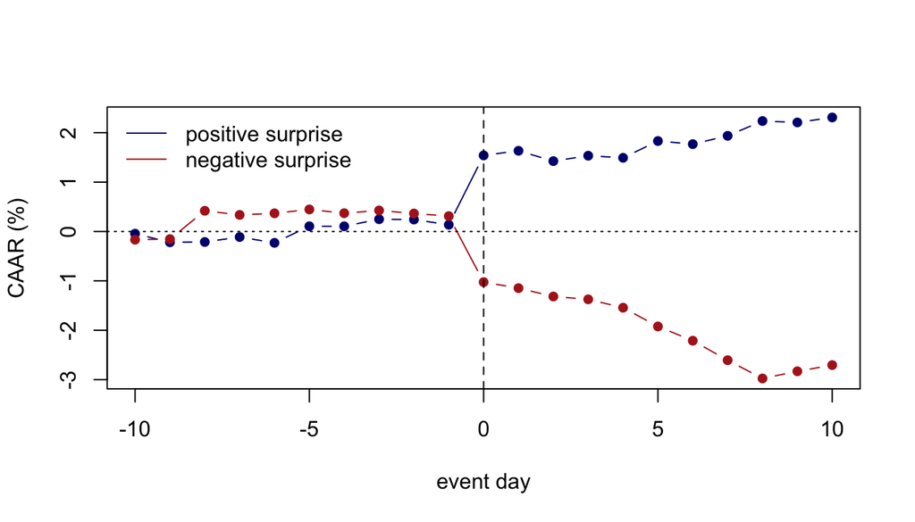

```r
agg <- ev[, .(AAR = mean(AR), CAAR = mean(CAR)), by = .(pos = S > 0, day)][order(pos, day)]
plot(agg[pos == TRUE, day], 100 * agg[pos == TRUE, CAAR], type = "b", pch = 16, col = "navy",
     ylim = 100 * range(agg$CAAR), xlab = "event day", ylab = "CAAR (%)")
lines(agg[pos == FALSE, day], 100 * agg[pos == FALSE, CAAR], type = "b", pch = 16, col = "firebrick")
abline(h = 0, lty = 3); abline(v = 0, lty = 2)
legend("topleft", bty = "n", legend = c("positive surprise", "negative surprise"), col = c("navy", "firebrick"), lwd = 1)
```

CARs over windows, with the cross-sectional $t$-statistic, and the earnings response coefficient:

```r
win <- function(k1, k2) ev[day >= k1 & day <= k2, .(CAR = sum(AR), s_hat = s_hat[1], S = S[1]), by = firm]
for (w in list(c(-10, -2), c(-1, 1), c(0, 10))) {
  z <- win(w[1], w[2])
  cat(sprintf("window [%3d,%3d]: CAAR = %6.2f%%  t = %5.2f   (S>0: %5.2f%%, S<0: %5.2f%%)\n",
              w[1], w[2], 100 * mean(z$CAR), mean(z$CAR) / (sd(z$CAR) / sqrt(nrow(z))),
              100 * mean(z[S > 0, CAR]), 100 * mean(z[S < 0, CAR])))
}
```

```
## window [-10, -2]: CAAR =   0.30%  t =  0.72   (S>0:  0.24%, S<0:  0.36%)
## window [ -1,  1]: CAAR =   0.01%  t =  0.05   (S>0:  1.39%, S<0: -1.51%)
## window [  0, 10]: CAAR =  -0.29%  t = -0.56   (S>0:  2.17%, S<0: -3.02%)
```

```r
feols(CAR ~ S, win(0, 10), vcov = "hetero")     # truth: slope 0.03
```

```
## OLS estimation, Dep. Var.: CAR
## Observations: 200
## Standard-errors: Heteroskedasticity-robust
##              Estimate Std. Error   t value   Pr(>|t|)
## (Intercept) -0.002302   0.004671 -0.492880 6.2264e-01
## S            0.032521   0.004579  7.101622 2.1642e-11 ***
## ---
## Signif. codes:  0 '***' 0.001 '**' 0.01 '*' 0.05 '.' 0.1 ' ' 1
## RMSE: 0.065396   Adj. R2: 0.19583
```

# In-class problem 4: clustered event dates

Every firm above announced on a different calendar day, so their abnormal returns are independent. Now suppose all 200 firms announce on the *same* day (think: earnings season compressed into one date, or a regulation that hits every bank at once). Simulate this by drawing **one** market-return series and giving it to every firm (replace the per-row `Rm` draw with a per-day draw shared across firms), and add a common shock of $-1\%$ to every firm’s return on day $0$ that has nothing to do with earnings.

1. Recompute the window $[0, 0]$ CAAR and its cross-sectional $t$-statistic for the full sample. What does the test conclude, and is it right?
2. Now regress $\text{CAR}_i(0, 0)$ on $S_i$. Is the *slope* still estimated correctly? Explain why the ERC survives what the average CAR does not.
3. What would you do differently in a real study where events cluster in time?

```r
# your code here
```